# Performing an onset-contingent analysis using eyetrackingR

Samuel Forbes, Jacob Dink & Brock Ferguson

2025-06-17

> **Our Experiment**: Each eyetrackingR vignette uses the *eyetrackingR* package to analyze real data from a simple 2-alternative forced choice (2AFC) word recognition task administered to 19- and 24-month-olds. On each trial, infants were shown a picture of an animate object (e.g., a horse) and an inanimate object (e.g., a spoon). After inspecting the images, they disappeared and they heard a label referring to one of them (e.g., “The horse is nearby!”). Finally, the objects re-appeared on the screen and they were prompted to look at the target (e.g., “Look at the horse!”).

## Overview of this vignette

In this vignette, we want to examine how quickly participants’ looked to the referent AOI (e.g., the Animate, when the Animate was named; the Inanimate, when the Inanimate was named) – i.e., to calculate their reaction times.

To do so, we can perform an onset-contingent looking analysis (e.g., Fernald et al., 2008), asking how quickly they *switched* from the AOI they were looking at from the onset of the trial when they happened to be looking at a non-target AOI. If participants were faster to switch from a distractor AOI to a target AOI than vice-verse, we can conclude that they were reliably identifying the target AOI.

Moreover, we can ask if this effect of onset-AOI (switching to/from the target) interacts with another predictor. *A priori*, we suspect they will be slower to switch away from the Animate (i.e., when the Inanimate was named) than to switch to the Animate (i.e., when the Animate was named) because, all things equal, infants prefer to look at animate things.

## Prerequisites

Before performing this analysis, we’ll need to prepare and clean our dataset. Here we will to do this quickly and with few notes but, for more information, see the vignette on preparing your data.

```r
set.seed(42)
library("Matrix")
library("lme4")
library("ggplot2")
library("eyetrackingR")
data("word_recognition")
data <- make_eyetrackingr_data(word_recognition,
                       participant_column = "ParticipantName",
                       trial_column = "Trial",
                       time_column = "TimeFromTrialOnset",
                       trackloss_column = "TrackLoss",
                       aoi_columns = c('Animate','Inanimate'),
                       treat_non_aoi_looks_as_missing = TRUE
)

# subset to response window post word-onset
response_window <- subset_by_window(data,
                                    window_start_time = 15500,
                                    window_end_time = 21000,
                                    rezero = FALSE)
```

```
## Avg. window length in new data will be 5500
```

```r
# analyze amount of trackloss by subjects and trials
(trackloss <- trackloss_analysis(data = response_window))

# remove trials with > 25% of trackloss
response_window_clean <- clean_by_trackloss(data = response_window, trial_prop_thresh = .25)
```

```
## Performing Trackloss Analysis...
```

```
## Will exclude trials whose trackloss proportion is greater than : 0.25
```

```
##  ...removed  33  trials.
```

```r
# create Target condition column
response_window_clean$Target <- as.factor( ifelse(test = grepl('(Spoon|Bottle)', response_window_clean$Trial),
                                       yes = 'Inanimate',
                                       no  = 'Animate') )
```

## Adding new columns

In order to perform this analysis, we need to add two new columns to our dataset to indicate the Target and Distractor AOIs *relative to the Target condition* for each trial.

```r
# recode AOIs to target & distractor
response_window_clean$TrialTarget <- ifelse(test = response_window_clean$Target == 'Animate',
                                            yes = response_window_clean$Animate,
                                            no = response_window_clean$Inanimate)
response_window_clean$TrialDistractor <- ifelse(test = response_window_clean$Target == 'Animate',
                                                yes = response_window_clean$Inanimate,
                                                no = response_window_clean$Animate)
```

## Visualize switches from an onset AOI to the target AOI

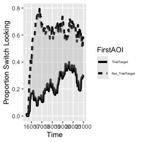

```r
onsets <- make_onset_data(response_window_clean, onset_time = 15500, target_aoi='TrialTarget')
# participants' ability to orient to the trial target overall:
plot(onsets) + theme(legend.text=element_text(size=5))
```

If we specify a predictor for this plot, we can examine visually whether infants’ performance in identifying the target varied by this predictor. Here, we want to know whether they more reliably switched to the target when the the Target was Animate versus Inanimate:

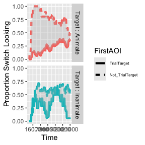

```r
# participants' ability to orient to the trial target, split by which target:
plot(onsets, predictor_columns = "Target") + theme(legend.text=element_text(size=6))
```

Infants were definitely more consistent and faster at switching *to* the Animate when it was named than away from it when the Inanimate was named, as expected.

Finally, we can ask whether infants with higher vocabularies outperformed infants with lower vocabularies, as indicated by their MCDI scores (note, for visualizing, the `plot` method performs a median split):

```
## Column 'MCDI_Total' is numeric, performing median split for visualization.
```

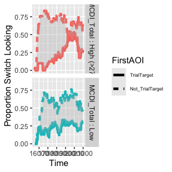

```r
# we can also visualize numeric predictors:
plot(onsets, predictor_columns = "MCDI_Total") + theme(legend.text=element_text(size=6))
```

## Analyze onset-contingent switch times

In order to analyze these switch times, we can calculate the switch times for target and non-target onset trials using `make_switch_data`.

We can then use a linear mixed-effects model to test three hypotheses:

1. That infants were faster/slower at switching to the target than away from the target (main effect of FirstAOI)
2. That infants were faster/slower to switch to *or* from the target when it was Animate or Inanimate (main effect of Target).
3. That infants were faster/slower at switching to the target when it was Animate or Inanimate (interaction between FirstAOI:Target)

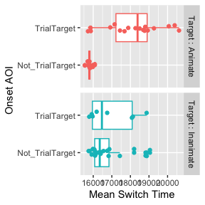

```r
onset_switches <- make_switch_data(onsets, predictor_columns = "Target")

# visualize subject's switch times
plot(onset_switches, predictor_columns = c("Target"))
```

```r
# center predictor:
onset_switches$FirstAOIC <- ifelse(onset_switches$FirstAOI == 'TrialTarget', .5, -.5)
onset_switches$FirstAOIC <- scale(onset_switches$FirstAOIC, center=TRUE, scale=FALSE)
onset_switches$TargetC <- ifelse(onset_switches$Target == 'Animate', .5, -.5)
onset_switches$TargetC <- scale(onset_switches$TargetC, center=TRUE, scale=FALSE)

# build model:
model_switches <- lmer(FirstSwitch ~ FirstAOIC*TargetC +
                (1 | Trial) + (1 | ParticipantName), data=onset_switches, REML=FALSE)
# cleanly show important parts of model (see `summary()` for more)
broom.mixed::tidy(model_switches, effects="fixed")
```

```
## # A tibble: 4 × 5
##   effect term              estimate std.error statistic
##   <chr>  <chr>                <dbl>     <dbl>     <dbl>
## 1 fixed  (Intercept)        17017.       152.   112.
## 2 fixed  FirstAOIC           1720.       239.     7.21
## 3 fixed  TargetC               61.0      251.     0.243
## 4 fixed  FirstAOIC:TargetC   2062.       520.     3.96
```

```r
drop1(model_switches,~.,test="Chi")
```

```
## boundary (singular) fit: see help('isSingular')
```

```
## Single term deletions
##
## Model:
## FirstSwitch ~ FirstAOIC * TargetC + (1 | Trial) + (1 | ParticipantName)
##                   npar    AIC    LRT   Pr(Chi)
## <none>                 1752.0
## FirstAOIC            1 1789.4 39.391 3.469e-10 ***
## TargetC              1 1750.1  0.059 0.8084704
## FirstAOIC:TargetC    1 1763.2 13.230 0.0002755 ***
## ---
## Signif. codes:  0 '***' 0.001 '**' 0.01 '*' 0.05 '.' 0.1 ' ' 1
```

The main effect of FirstAOIC reveals that participants were more likely to switch to the target than away from it, overall, which suggests overall they could identify the target referent of these words. The interaction here with TargetC, however, reveals that infants were faster to switch to the Animate when it was named than away from the Animate when the Inanimate was named.

## References

Fernald, A., Zangl, R., Portillo, A. L., & Marchman, V. A. (2008). Looking while listening: Using eye movements to monitor spoken language comprehension by infants and young children. In I. A. Sekerina, E. M. Fernández, & H. Clahsen (Eds.), Developmental Psycholinguistics: On-line methods in children’s language processing (pp. 97–135). Amsterdam: John Benjamins.

Yurovsky, D., & Frank, M. C. (2015). Beyond Naïve Cue Combination: Salience and Social Cues in Early Word Learning. Developmental Science, 1–38.